# Latent Risk Prediction

Gabriel Hernandez

October 2023

# Introduction

A generalizable geospatial risk prediction model predicts latent risk with comparable accuracy across different neighborhoods. Our goal here is to build a model that can identify areas at risk for incidents of theft even if there have not been any reported yet. The purpose of our model is to cover for any selection bias in the reported data. A selection bias takes place when inputs and decision makers suffer from inequities and arbitrary choices that discount the true quantity of observed incidents, resulting in incomplete data. Our model will correlate theft with features of the built environment and then predict latent risk across the city of Chicago. We will then compare our model to the business-as-usual approach that results in the perpetuation of place-based injustices from over-policing.

```r
policeDistricts <-
  st_read("https://data.cityofchicago.org/api/geospatial/fthy-xz3r?method=export&format=GeoJSON") %>%
  st_transform('ESRI:102271') %>%
  dplyr::select(District = dist_num)

policeBeats <-
  st_read("https://data.cityofchicago.org/api/geospatial/aerh-rz74?method=export&format=GeoJSON") %>%
  st_transform('ESRI:102271') %>%
  dplyr::select(District = beat_num)

bothPoliceUnits <- rbind(mutate(policeDistricts, Legend = "Police Districts"),
                         mutate(policeBeats, Legend = "Police Beats"))

crimeData <- read.socrata("https://data.cityofchicago.org/Public-Safety/Crimes-2017/d62x-nvdr")

thefts <- crimeData %>%
    filter(Primary.Type == "THEFT") %>%
    mutate(x = gsub("[()]", "", Location)) %>%
    separate(x,into= c("Y","X"), sep=",") %>%
    mutate(X = as.numeric(X),Y = as.numeric(Y)) %>%
    na.omit() %>%
    st_as_sf(coords = c("X", "Y"), crs = 4326, agr = "constant")%>%
    st_transform(crs=crs) %>%
    distinct()

chicagoBoundary <-
  st_read(file.path(root.dir,"/Chapter5/chicagoBoundary.geojson")) %>%
  st_transform(crs=crs)
```

# Exploratory Analysis

## Point Map of Reported Thefts

The map that we created to visualize theft in Chicago for the year 2017 does not show a lot at first glance. It is cluttered, with incidents of theft being reported across the city. But when we continue to look at it, a couple of patterns become evident. First, whereas in most of the city there are percolations of incidents, others have a rainstorm of incidents. One such area is the downtown center of the city, and another is in the River North area. Moving inland from these areas, the distribution wanes because crime risk tends to dissipate from hotspots. This could be a function of proximity to the night-time economy, which unfortunately presents the opportunist thieve with vulnerable populations to target. It is no secret that the consumption of mind-state altering substances can lead to a lack of awareness. Furthermore, the same area may have more stores. An opportunistic thieve could take advantage of daytime consumers walking around with bags in their hands. Moreover, another factor that might affect the distribution that we see on the map is under-reporting due to selection bias. From our understanding, southside Chicago has a history of experience with violence and disinvestment. In some cases it has lead to a lack of trust in the local police and therefore presents a selection bias in that incidents of theft go unreported. From my own experience, some communities might rather deal with incidents of theft personally as opposed to coming into contact with the authorities. Conversely, because wealthier communities tend to be more territorial and dependent on local policing to accomplish neighborhood safety and the protection of land values, there could be a disproportionately high rate of reporting in these areas compared to the rest of Chicago.

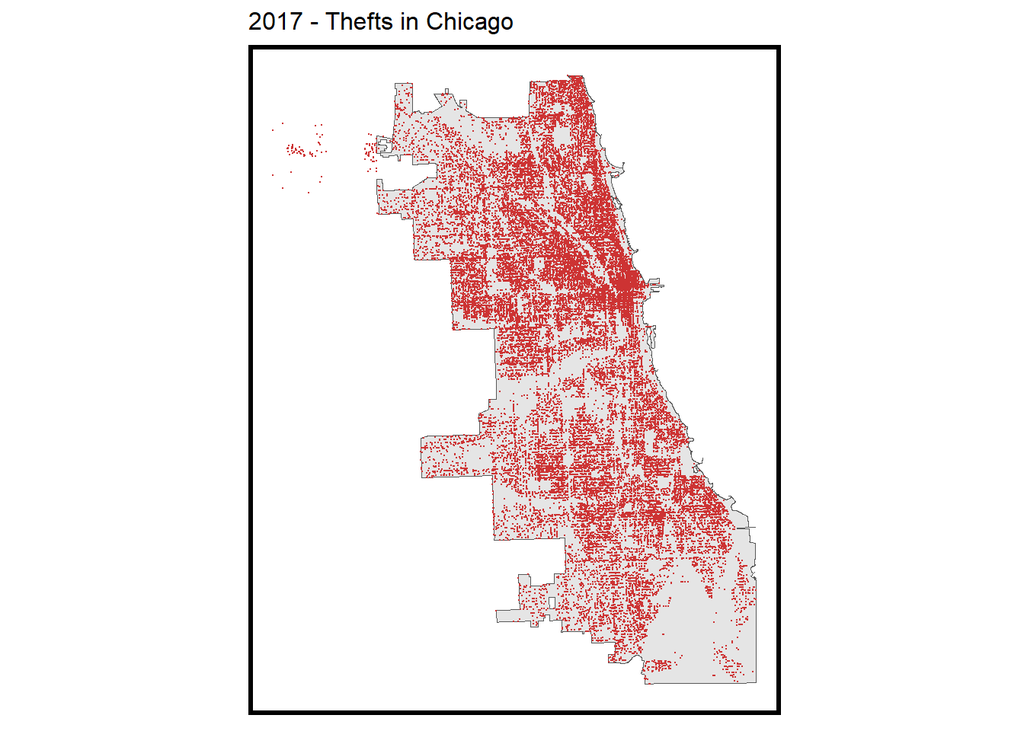

```r
ggplot() +
  geom_sf(data = chicagoBoundary) +
  geom_sf(data = thefts, colour="brown3", size=0.01, show.legend = "point") +
  labs(title= "2017 - Thefts in Chicago") +
  mapTheme(title_size = 12)
```

## Fishnet Visualization of Theft Data

The following code creates a 500ft x 500ft fishnet overlay for the city of Chicago and join spatially each incident of theft to its corresponding cell, and calculating the total count of incidents per cell. This helps us capture more accurately the landscape of crime risk as opposed to using police districts or police beats We then mapped the distribution of counts to identify areas with high concentrations of theft. We can confirm that that concentration of theft takes place in the dense commercial hub of the city.

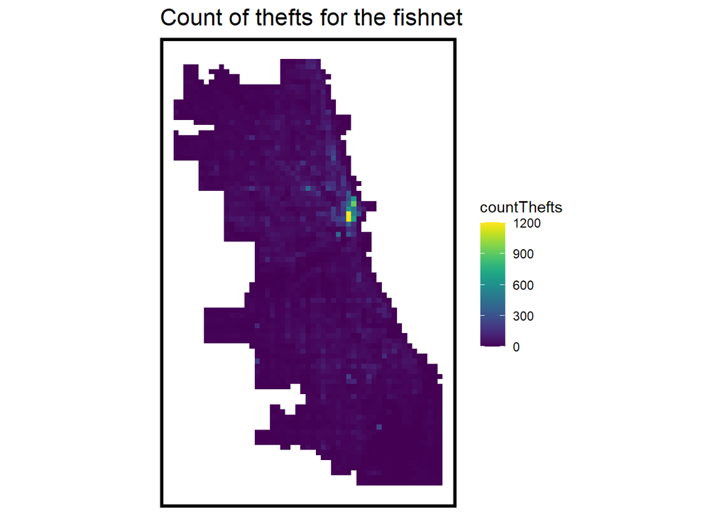

```r
fishnet <-
  st_make_grid(chicagoBoundary,
               cellsize = 500, square = TRUE) %>%
  .[chicagoBoundary] %>%   #quickly select intersecting polygons
  st_sf() %>%
  mutate(uniqueID = 1:n()) #create ID for each cell that will be joined

crime_net <-
  dplyr::select(thefts) %>%
  mutate(countThefts = 1) %>%
  aggregate(., fishnet, sum) %>% #spatial join that sums the count of thefts for each cell
  mutate(countThefts = replace_na(countThefts, 0),
         uniqueID = 1:n(),
         cvID = sample(round(nrow(fishnet) / 24),
                       size=nrow(fishnet), replace = TRUE))
#map of fishnet

ggplot() +
  geom_sf(data = crime_net, aes(fill = countThefts), color = NA) +
  scale_fill_viridis() +
  labs(title = "Count of thefts for the fishnet") +
  mapTheme()
```

# Selected Spatial Features

Our prediction model uses the theory of exposure to predict where thefts may take place in the city. This is meant to build on the business as usual approach, which is based solely on policing areas where incidents occur. Again, our goal is to create a model that predicts the latent risk for theft in the city. To do this, we bring in features that can account for the exposure

To build our theft prediction model, we pulled in 311 request data for vacant and abandoned buildings, broken street lights, and sanitation complaints. All three of these can serve as markers of urban decay and disinvestment and have been associated with prevalence of crimes. We also brought in the locations of liquor retailers and affordable housing developments. Crime itself can be related to dark places and proximity to pipelines for substance abuse such as liquor stores. Crime is also sometimes a response to the experience of poverty and affordable housing projects many times are found in areas with high needs for community development. The data above, as well as neighborhood boundaries, were obtained from the Chicago Data Portal.

Below are maps that show the distance between each cell in our fishnet and the nearest amount of a particular risk factor. In choosing how many neighbors to assign each risk factor there is an opportunity for bias. I am answering the question: would the difference between areas be captured when I measure the distance to the nearest 5 of any risk factor versus 20 of them. This decision is arbitrary and would require multiple attempts of exploration in future analysis.

```r
streetLightsOut <-
  read.socrata("https://data.cityofchicago.org/Service-Requests/311-Service-Requests-Street-Lights-All-Out/zuxi-7xem") %>%
    mutate(year = substr(creation_date,1,4)) %>% filter(year == "2017") %>%
    dplyr::select(Y = latitude, X = longitude) %>%
    na.omit() %>%
    st_as_sf(coords = c("X", "Y"), crs = 4326, agr = "constant") %>%
    st_transform(st_crs(fishnet)) %>%
    mutate(Legend = "Street_Lights_Out")

abandonBuildings <- read.socrata("https://data.cityofchicago.org/Service-Requests/311-Service-Requests-Vacant-and-Abandoned-Building/7nii-7srd") %>%
    mutate(year = substr(date_service_request_was_received,1,4)) %>% filter(year == "2017") %>%
    dplyr::select(Y = latitude, X = longitude) %>%
    na.omit() %>%
    st_as_sf(coords = c("X", "Y"), crs = 4326, agr = "constant") %>%
    st_transform(st_crs(fishnet)) %>%
    mutate(Legend = "Abandoned_Buildings")

liquorRetail <-
  read.socrata("https://data.cityofchicago.org/resource/nrmj-3kcf.json") %>%
    filter(business_activity == "Retail Sales of Packaged Liquor") %>%
    dplyr::select(Y = latitude, X = longitude) %>%
    na.omit() %>%
    st_as_sf(coords = c("X", "Y"), crs = 4326, agr = "constant") %>%
    st_transform(st_crs(fishnet)) %>%
    mutate(Legend = "Liquor_Retail")

sanitation <-
  read.socrata("https://data.cityofchicago.org/Service-Requests/311-Service-Requests-Sanitation-Code-Complaints-Hi/me59-5fac") %>%
    mutate(year = substr(creation_date,1,4)) %>% filter(year == "2017") %>%
    dplyr::select(Y = latitude, X = longitude) %>%
    na.omit() %>%
    st_as_sf(coords = c("X", "Y"), crs = 4326, agr = "constant") %>%
    st_transform(st_crs(fishnet)) %>%
    mutate(Legend = "Sanitation")
#new features


affordHousing <-
  read.socrata("https://data.cityofchicago.org/resource/s6ha-ppgi.json") %>%
    dplyr::select(Y = latitude, X = longitude) %>%
    na.omit() %>%
    st_as_sf(coords = c("X", "Y"), crs = 4326, agr = "constant") %>%
    st_transform(st_crs(fishnet)) %>%
    mutate(Legend = "Affordable_Housing")

#forlater:
neighborhoods <-
  st_read("https://raw.githubusercontent.com/blackmad/neighborhoods/master/chicago.geojson") %>%
  st_transform(st_crs(fishnet))

vars_net <-
  rbind(abandonBuildings,streetLightsOut,affordHousing,liquorRetail, sanitation) %>%
  st_join(., fishnet, join=st_within) %>%
  st_drop_geometry() %>%
  group_by(uniqueID, Legend) %>%
  summarize(count = n()) %>%
    full_join(fishnet) %>%
    spread(Legend, count, fill=0) %>%
    st_sf() %>%
    dplyr::select(-`<NA>`) %>%
    na.omit() %>%
    ungroup()
```

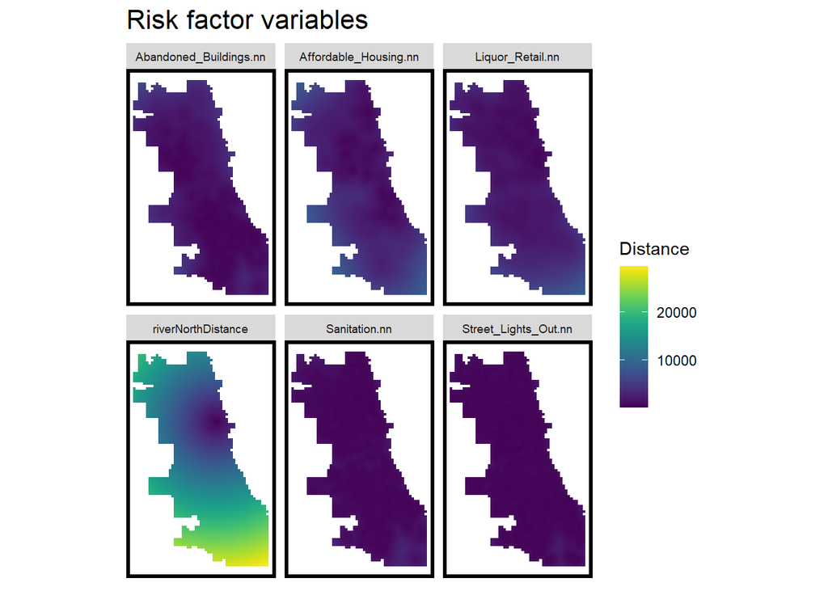

```r
st_c    <- st_coordinates
st_coid <- st_centroid

## create NN for variables
vars_net <- vars_net %>%
    mutate(
      Abandoned_Buildings.nn =
        nn_function(st_c(st_coid(vars_net)), st_c(abandonBuildings), 20),
      Liquor_Retail.nn =
        nn_function(st_c(st_coid(vars_net)), st_c(liquorRetail),20),
      Street_Lights_Out.nn =
        nn_function(st_c(st_coid(vars_net)), st_c(streetLightsOut),20),
      Sanitation.nn =
        nn_function(st_c(st_coid(vars_net)), st_c(sanitation),50),
      Affordable_Housing.nn =
        nn_function(st_c(st_coid(vars_net)), st_c(affordHousing),20))

riverNorthPoint <-
  filter(neighborhoods, name == "River North") %>%
  st_centroid()

vars_net$riverNorthDistance =
  st_distance(st_centroid(vars_net),riverNorthPoint) %>%
  as.numeric()

vars_net.long.nn <-
  dplyr::select(vars_net, ends_with(".nn"), riverNorthDistance) %>%
    gather(Variable, value, -geometry)


ggplot() +
      geom_sf(data = vars_net.long.nn, aes(fill=value), colour=NA) +
      scale_fill_viridis(name="Distance") +
      labs(title="Risk factor variables") +
      facet_wrap(~Variable, nrow=2) +
      mapTheme() +
      theme(strip.text.x = element_text(size = 7))
```

```r
#combining observed crime w the risk factors

final_net <-
  left_join(crime_net, st_drop_geometry(vars_net), by="uniqueID")

final_net <-
  st_centroid(final_net) %>%
    st_join(dplyr::select(neighborhoods, name), by = "uniqueID") %>%
    st_join(dplyr::select(policeDistricts, District), by = "uniqueID") %>%
      st_drop_geometry() %>%
      left_join(dplyr::select(final_net, geometry, uniqueID)) %>%
      st_sf() %>%
  na.omit()
```

## Local Moran’s I-related small multiple map of your outcome

With Local Moran’s I, the null hypothesis is that the count of thefts at a given location is randomly distributed relative to its immediate neighbors. The definition of “neighbor”” introduces another moment where there can be bias in the analysis, in our case, we chose queen neighbors. The maps below describe the local spatial process of theft. High values of I represent strong and statistically significant evidence of local clustering, meaning where there are spots that present a higher risk of theft. We define significant hotspots as those with p-values below .005. I originally used 0.05 but noticed that 0.005 was more precise and did not take a lot away from the results at p=0.01.

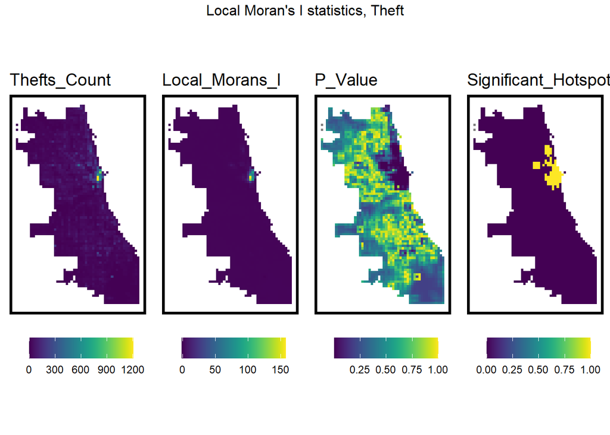

```r
## {spdep} to make polygon to neighborhoods...

final_net.nb <- poly2nb(as_Spatial(final_net), queen=TRUE)

## list
final_net.weights <- nb2listw(final_net.nb, style="W", zero.policy=TRUE)

local_morans <- localmoran(final_net$countThefts, final_net.weights, zero.policy=TRUE) %>%
  as.data.frame()

# Join test results to the final net
final_net.localMorans <-
  cbind(local_morans, as.data.frame(final_net)) %>%
  st_sf() %>%
  dplyr::select(Thefts_Count = countThefts,
                Local_Morans_I = Ii,
                P_Value = `Pr(z != E(Ii))`) %>%
  mutate(Significant_Hotspots = ifelse(P_Value <= 0.005, 1, 0)) %>%
  gather(Variable, Value, -geometry)

## preparing empty map list based on each variable
vars <- unique(final_net.localMorans$Variable)
varList <- list()

for(i in vars){
  varList[[i]] <-
    ggplot() +
      geom_sf(data = filter(final_net.localMorans, Variable == i),
              aes(fill = Value), colour=NA) +
      scale_fill_viridis(name="") +
      labs(title=i) +
      mapTheme(title_size = 14) + theme(legend.position="bottom")}

do.call(grid.arrange,c(varList, ncol = 4, top = "Local Moran's I statistics, Theft"))
```

```r
#add on

final_net <- final_net %>%
  mutate(theft.isSig =
           ifelse(local_morans[,5] <= 0.01, 1, 0)) %>%
  mutate(theft.isSig.dist =
           nn_function(st_c(st_coid(final_net)),
                       st_c(st_coid(filter(final_net,
                                           theft.isSig == 1))),
                       k = 1))
```

## A small multiple scatterplot with correlations.

These scatterplots visualize the relationship between theft count and each of the predictors and engineered features in the model for each cell in our fishnet. Each of the variables has a weak negative correlation to the count of thefts. The larger the distance between neighbors, the less the chance of crime. Abandoned building nearest neighbor distance stands out as not having much correlation with theft count. This could be because if buildings are abandoned, then there aren’t as many people to steal from in the first place. This supports our main finding that the tourist/commercial center is where there are a significant amount of thefts. We chose to maintain the distances from the cell to the nearest risk factors as opposed to their count per cell because it introduces a location fixed effect that improves our model. The scatter plots suggest that the likelihood of theft decreases the further that you get from liquor stores, affordable housing developments, street light outages, and the further that you get from the River North area.

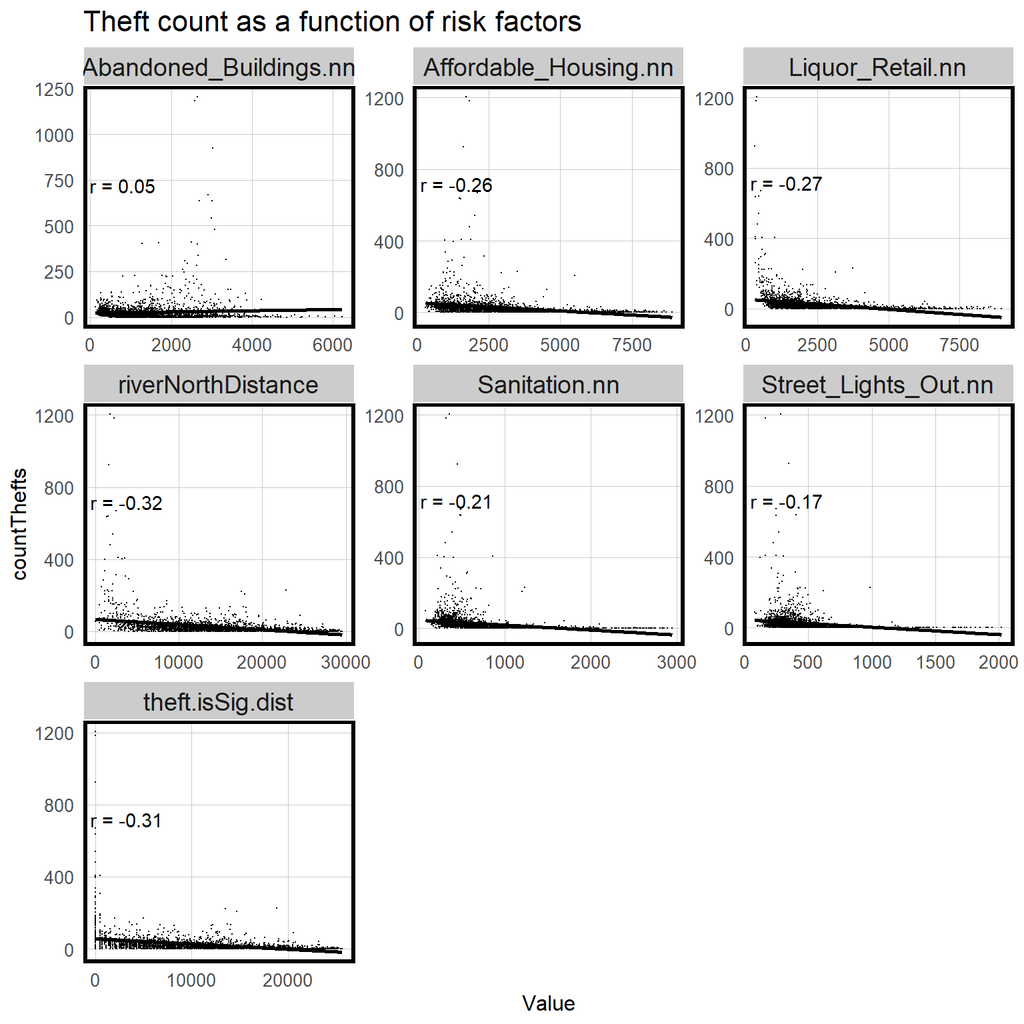

```r
correlation.long <-
  st_drop_geometry(final_net) %>%
    dplyr::select(-uniqueID, -cvID, -name, -District,
                  -Abandoned_Buildings, -Affordable_Housing, -Liquor_Retail,
                  -Sanitation, -Street_Lights_Out,
                  -theft.isSig) %>%
    gather(Variable, Value, -countThefts)

correlation.cor <-
  correlation.long %>%
    group_by(Variable) %>%
    summarize(correlation = cor(Value, countThefts, use = "complete.obs"))

ggplot(correlation.long, aes(Value, countThefts)) +
  geom_point(size = 0.1) +
  geom_text(data = correlation.cor, aes(label = paste("r =", round(correlation, 2))),
            x=-Inf, y=800, vjust = 1.5, hjust = -.1) +
  geom_smooth(method = "lm", se = FALSE, colour = "black") +
  facet_wrap(~Variable, ncol = 3, scales = "free") +
  labs(title = "Theft count as a function of risk factors",
       strip.text.x = element_text(size=10)) +
  plotTheme()
```

## A histogram of your dependent variable.

To determine which type of regression we should run, we have to know the distribution of the variable that we want to regress on. In this case it is theft, which the following histogram visualizes as a skewed, Poisson distribution. There are many cells that have 0 thefts, so naturally the results cluster towards the origin of the histogram. Thus we will use the Poisson regression in our model.

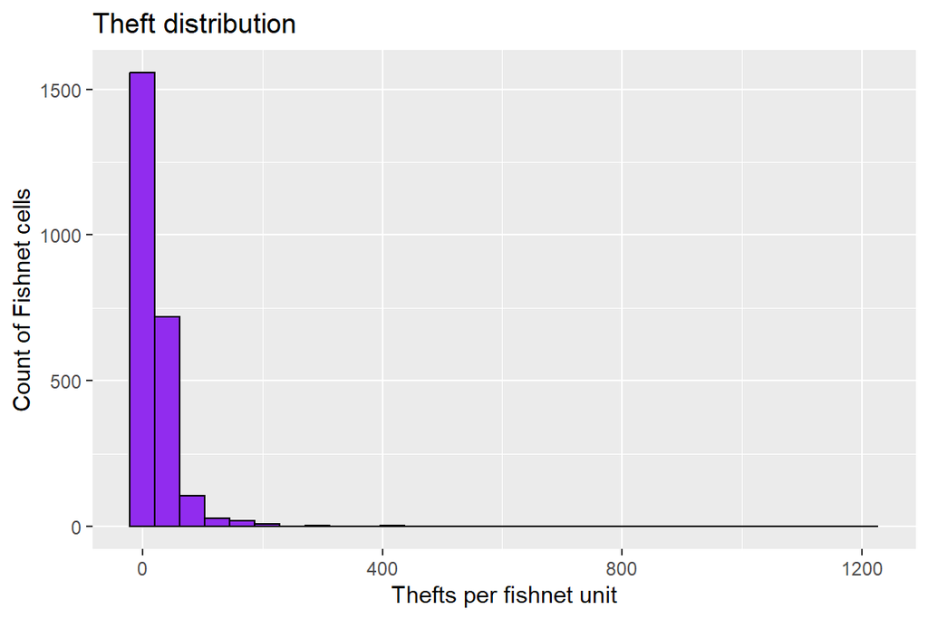

```r
ggplot(crime_net) +
  geom_histogram(bins = 30, colour="black", fill = "purple2") +
  aes(countThefts) +
    labs(title="Theft distribution",
         x="Thefts per fishnet unit", y="Count of Fishnet cells")
```

# Accuracy by Risk Model: Incorporating Local Moran’s I

A well-generalized crime predictive model learns the crime risk “experience” at both citywide and local spatial scales. In this model we are concerned with spatial predictions so we will perform spatial cross validation. Namely, we will use the leave-one-group-out cross validation technique (LOGO CV) that trains the model on all the neighborhoods except the one that is”left out”, which represents the test set. The function iterates the process, each time leaving out a different areal unit until all have been test on and the results get recorded. Below we will compare the results of this process for multiple unit scales: fishnet cells using random k-fold cross validation and neighborhoods which we call the spatial LOGO cross-validation. We will further split these cross-validations between ones that involve the Local Morans I test results which include our “hot spots” and the distance to them. We refer to these as involving “spatial process”.

## Summary of Regression Type Performance

```r
reg.summary <-
  rbind(
    mutate(reg.cv,           Error = Prediction - countThefts,
                             Regression = "Random k-fold CV: Just Risk Factors"),

    mutate(reg.ss.cv,        Error = Prediction - countThefts,
                             Regression = "Random k-fold CV: Spatial Process"),

    mutate(reg.spatialCV,    Error = Prediction - countThefts,
                             Regression = "Spatial LOGO-CV: Just Risk Factors"),

    mutate(reg.ss.spatialCV, Error = Prediction - countThefts,
                             Regression = "Spatial LOGO-CV: Spatial Process")) %>%
    st_sf()

error_by_reg_and_fold <-
  reg.summary %>%
    group_by(Regression, cvID) %>%
    summarize(Mean_Error = mean(Prediction - countThefts, na.rm = T),
              MAE = mean(abs(Mean_Error), na.rm = T),
              SD_MAE = mean(abs(Mean_Error), na.rm = T)) %>%
  ungroup()

st_drop_geometry(error_by_reg_and_fold) %>%
  group_by(Regression) %>%
    summarize(Mean_MAE = round(mean(MAE), 2),
              SD_MAE = round(sd(MAE), 2)) %>%
  kable() %>%
    kable_styling("striped", full_width = F) %>%
    row_spec(2, color = "black", background = "#FDE725FF") %>%
    row_spec(4, color = "black", background = "#FDE725FF")
```

| Regression | Mean_MAE | SD_MAE |
| --- | --- | --- |
| Random k-fold CV: Just Risk Factors | 7.26 | 6.59 |
| Random k-fold CV: Spatial Process | 6.29 | 6.53 |
| Spatial LOGO-CV: Just Risk Factors | 28.86 | 63.76 |
| Spatial LOGO-CV: Spatial Process | 21.54 | 52.48 |

## Model Errors Across Space:

These maps visualize the errors from our cross validation when the local spatial process is accounted for and when it isn’t for both our fishnet cells and our neighborhoods feature. Not only is there a reduction of errors, but it is also easier to see where they are occurring. It is difficult to explain the errors in the k-fold errors because they seem more random. Contrast this with the neighborhood level LOGO cross validation, where we see that most of the errors are occuring near the same hot spots that we identified earlier r, and low errors across the rest of Chicago. It feels a bit counter intuitive but it could be that the low counts in the other neighborhoods influence the model in a way that underpredicts the results on the higher end of observed counts. Given that our risk factors did not have a strong correlation to theft counts, better features could influence our model in a way that reduces the errors at the high end of our observations and further flattening of the low end. This can become a problem where we do not allocate as many resources as neccesary to hotspot zones.

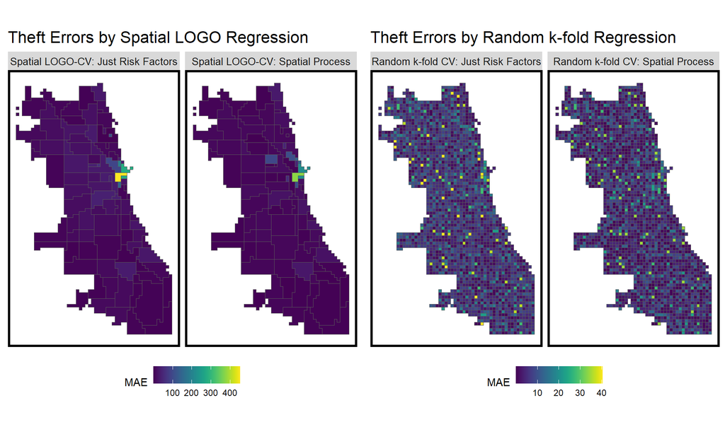

```r
grid.arrange(ncol=2,
error_by_reg_and_fold %>%
  filter(str_detect(Regression, "LOGO")) %>%
  ggplot() +
    geom_sf(aes(fill = MAE)) +
    facet_wrap(~Regression) +
    scale_fill_viridis() +
    labs(title = "Theft Errors by Spatial LOGO Regression") +
    mapTheme() + theme(legend.position="bottom",
                       strip.text.x = element_text(size = 10)),
error_by_reg_and_fold %>%
  filter(str_detect(Regression, "Random")) %>%
  ggplot() +
    geom_sf(aes(fill = MAE)) +
    facet_wrap(~Regression) +
    scale_fill_viridis() +
    labs(title = "Theft Errors by Random k-fold Regression") +
    mapTheme() + theme(legend.position="bottom",
                       strip.text.x = element_text(size = 10))
)
```

# Generalizability

The generalizability of determines how powerful it is. If it is able to generalize across contexts then it is both fair and worth using. When we look at the errors across contexts, they should be quite similar, otherwise there have to be more features created and included that can account for the observed differences.

```r
#rounded

#Census Data for Race Context
tracts18 <-
  get_acs(geography = "tract", variables = c("B01001_001E","B01001A_001E"),
          year = 2018, state=17, county=031, geometry=T) %>%
  st_transform(crs=crs)  %>%
  dplyr::select(variable, estimate, GEOID) %>%
  spread(variable, estimate) %>%
  rename(TotalPop = B01001_001,
         NumberWhites = B01001A_001) %>%
  mutate(percentWhite = NumberWhites / TotalPop,
         raceContext = ifelse(percentWhite > .50, "Majority_White", "Majority_Non_White")) %>%
  .[neighborhoods,]
  reg.summary %>%
    st_centroid() %>%
    st_join(tracts18) %>%
    na.omit() %>%
      st_drop_geometry() %>%
      group_by(Regression, raceContext) %>%
      summarize(mean.Error = round(mean(Error, na.rm = T),3)) %>%
      spread(raceContext, mean.Error) %>%
      kable(caption = "Mean Error by Racial Context") %>%
        kable_styling("striped", full_width = F)%>%
        row_spec(row=2, color = "black", background = "#FDE725FF") %>%
        row_spec(row=4, color = "black", background = "#FDE725FF")
```

Mean Error by Racial Context

| Regression | Majority_Non_White | Majority_White |
| --- | --- | --- |
| Random k-fold CV: Just Risk Factors | 0.272 | -0.344 |
| Random k-fold CV: Spatial Process | 0.169 | -0.240 |
| Spatial LOGO-CV: Just Risk Factors | 0.358 | -0.302 |
| Spatial LOGO-CV: Spatial Process | 0.219 | -0.085 |

# Comparing to the Business-as-Usual Approach

Kernel Density is the traditional technique used to predict hotspots based on observed data. It relies heavily spatial autocorrelation, as opposed to our risk-prediction model which takes into account the city-wide experience of Chicago that recognizes that a variety of factors interact across space to produce a healhty environment for thefts to occur. Furthermore, when using kernel density, the researcher uses a search radii, which introduces bias into the results of where the hot spots are.

We created maps that overlay observed thefts in 2018 on both a traditional kernel density prediction model and our risk factor model.For each grid cell and model type there is a risk category based on the count of thefts. We perform an eye test to determine if our model targets the highest risk category well, indicating that it performs well.

The kernel density does not identify high risk categories on the peripheral of the River north area, indicating the limitation of using it compared to the risk prediction model that accounts for the city wide experience. Our model is better equipped to probe at-risk areas. At the same time, there are high risk areas that do not have as many points, like those west of the River North area.

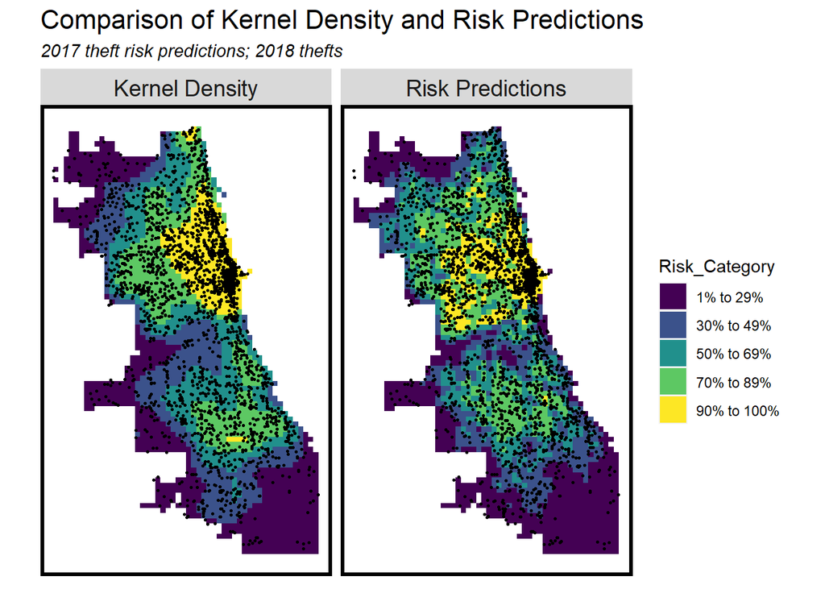

```r
thefts18 <-
  read.socrata("https://data.cityofchicago.org/Public-Safety/Crimes-2018/3i3m-jwuy") %>%
  filter(Primary.Type == "THEFT") %>%
  mutate(x = gsub("[()]", "", Location)) %>%
  separate(x,into= c("Y","X"), sep=",") %>%
  mutate(X = as.numeric(X),
         Y = as.numeric(Y)) %>%
  na.omit %>%
  st_as_sf(coords = c("X", "Y"), crs = 4326, agr = "constant") %>%
  st_transform(crs=crs) %>%
  distinct() %>%
  .[fishnet,]

theft_ppp <- as.ppp(st_coordinates(thefts), W = st_bbox(final_net))
theft_KD <- spatstat.explore::density.ppp(theft_ppp, 1000)

theft_KDE_sf <- as.data.frame(theft_KD) %>%
  st_as_sf(coords = c("x", "y"), crs = st_crs(final_net)) %>%
  aggregate(., final_net, mean) %>%
  mutate(label = "Kernel Density",
         Risk_Category = ntile(value, 100),
         Risk_Category = case_when(
           Risk_Category >= 90 ~ "90% to 100%",
           Risk_Category >= 70 & Risk_Category <= 89 ~ "70% to 89%",
           Risk_Category >= 50 & Risk_Category <= 69 ~ "50% to 69%",
           Risk_Category >= 30 & Risk_Category <= 49 ~ "30% to 49%",
           Risk_Category >= 1 & Risk_Category <= 29 ~ "1% to 29%")) %>%
  cbind(
    aggregate(
      dplyr::select(thefts18) %>% mutate(theftCount = 1), ., sum) %>%
    mutate(theftCount = replace_na(theftCount, 0))) %>%
  dplyr::select(label, Risk_Category, theftCount)

theft_risk_sf <-
  filter(reg.summary, Regression == "Spatial LOGO-CV: Spatial Process") %>%
  mutate(label = "Risk Predictions",
         Risk_Category = ntile(Prediction, 100),
         Risk_Category = case_when(
           Risk_Category >= 90 ~ "90% to 100%",
           Risk_Category >= 70 & Risk_Category <= 89 ~ "70% to 89%",
           Risk_Category >= 50 & Risk_Category <= 69 ~ "50% to 69%",
           Risk_Category >= 30 & Risk_Category <= 49 ~ "30% to 49%",
           Risk_Category >= 1 & Risk_Category <= 29 ~ "1% to 29%")) %>%
  cbind(
    aggregate(
      dplyr::select(thefts18) %>% mutate(theftCount = 1), ., sum) %>%
      mutate(theftCount = replace_na(theftCount, 0))) %>%
  dplyr::select(label,Risk_Category, theftCount)

rbind(theft_KDE_sf, theft_risk_sf) %>%
  na.omit() %>%
  gather(Variable, Value, -label, -Risk_Category, -geometry) %>%
  ggplot() +
    geom_sf(aes(fill = Risk_Category), colour = NA) +
    geom_sf(data = sample_n(thefts18, 3000), size = .5, colour = "black") +
    facet_wrap(~label, ) +
    scale_fill_viridis(discrete = TRUE) +
    labs(title="Comparison of Kernel Density and Risk Predictions",
         subtitle="2017 theft risk predictions; 2018 thefts") +
    mapTheme()
```

## Bar Plot comparison

Another way to compare the kernel density model with our risk prediction model is through the use of a bar plot that shows, for each risk category, how many thefts were accurately predicted. If risk predictions capture more of the observed thefts than the kernel density, then the risk prediction model provides a more robust tool for allocating police resources.

What we see is that our model better captures thefts at the lower risk areas but underperforms compared to the kernel density model at the higher risk category. This inverse relationship is interesting, and reflects how our model showed higher errors in the areas that are hotspots, a.k.a the higher risk areas. With the improvement of features it is very possible that we could close the gap with the kernel density model. It is also worth noting that the performance of the kernel density could be due to its focus in pre-exiting hot spot areas, compared to ours which identifies possible high risk areas in other parts of the city. The message each is the same: focus on that hotspot, but ours offers the more insight into where the police department should keep an eye on.

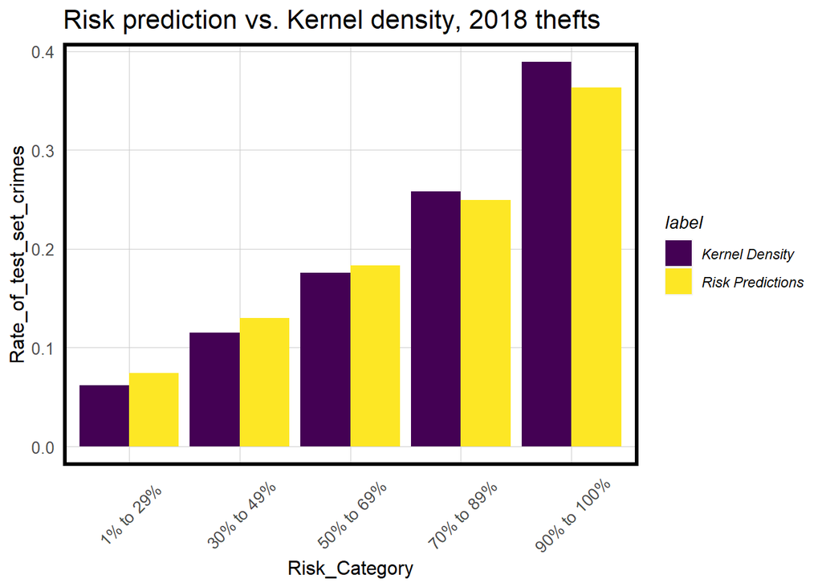

```r
rbind(theft_KDE_sf, theft_risk_sf) %>%
  st_set_geometry(NULL) %>% na.omit() %>%
  gather(Variable, Value, -label, -Risk_Category) %>%
  group_by(label, Risk_Category) %>%
  summarize(countThefts = sum(Value)) %>%
  ungroup() %>%
  group_by(label) %>%
  mutate(Rate_of_test_set_crimes = countThefts / sum(countThefts)) %>%
    ggplot(aes(Risk_Category,Rate_of_test_set_crimes)) +
      geom_bar(aes(fill=label), position="dodge", stat="identity") +
      scale_fill_viridis(discrete = TRUE) +
      labs(title = "Risk prediction vs. Kernel density, 2018 thefts") +
      plotTheme() + theme(axis.text.x = element_text(angle = 45, vjust = 0.5))
```